# A Geometric Interpretatyion of Population Genetic Structure

Author

Affiliation

[Rodney J. Dyer](https://dyerlab.org)

Center for Environmental Studies  
Virginia Commonwealth University  
Richmond, Virginia 23284, USA

Published

October 10, 2022

Abstract

An estimate of the amount of genetic variation in a sampled locale is often based upon the standardized mean divergence in allele frequencies as manifest in statistics such as F<sub>ST</sub> and their ilk. While informative, and indeed rooted in the foundations of evolutionary theory, simple abstractions such as these may be insensitive to more nuanced components of genetic structure due to their robustness—it is well understood that a specific value of F<sub>ST</sub> may represent an infinite number of population arrangements, all of which just happen to have the same ratio of among to within population genetic variance. This manuscript is the first in a pair focusing on a geometric interpretation of population genetic structure, the benefit of which may provide praticioneers of popualtion genetic studies additional tools and a broader understanding of standing structure.

## Introduction

The mapping of genotypes -> estimates of both within locale diversity and among local structure are a fundamental component of population and landscape genetic analyses, and indeed the formulation for our understanding of how evolution proceeds.

A common method for measuring structure is from Sewell Wright ’s $F_{st}$ statistic and its offspring. At heart, the parameters is defined as the fraction of the total genetic variance that can be contributed to individuals being in different populations. This parameter has many offspring but in its most general form, it can be defined as the ratio of the among locale variance in allele frequencies standardized by the variance in the global allele frequencies. For a single locus, this becomes.

$$F_{ST} = \frac{\sum_{i=1}^\ell \sigma_{q_{S(i)}}^2}{\sum_{i=1}^\ell \left[ q_{T(i)} (1 - q_{T(i)}) \right]}$$

Originally, Wright suggested that this should probably not be thought of in the way that most of us see ‘differentiation’. To demonstrate this, Wright showed the several examples where populations can be considered to be completely fixed for different alleles resulting in an estimate of $F_{ST} = 1.0$. This is true for various configurations of fixed 2-allele systems including the trivial 2-locale system.

| Locale | f(a) | f(b) |
| --- | --- | --- |
| 1 | 1.0 | 0.0 |
| 2 | 0.0 | 1.0 |
| $\sum \sigma^2_{q_s}$ |  | 0.50 |
| $\sum [ q_t (1-q_t)]$ |  | 0.50 |
| $F_{ST}$ |  | 1.0 |

As well as a more complicated system with four locales, three of which are fixed for the same allele (and by themselves would have $F_{ST} = 0.0$), and the fourth population fixed for an alternative allele.

| Locale | f(a) | f(b) |
| --- | --- | --- |
| 1 | 1.0 | 0.0 |
| 2 | 0.0 | 1.0 |
| 3 | 0.0 | 1.0 |
| 4 | 0.0 | 1.0 |
| $\sum \sigma^2_{q_s}$ |  | 0.375 |
| $\sum [ q_t (1-q_t)]$ |  | 0.375 |
| $F_{ST}$ |  | 1.0 |

Even without fixation, it is possible to show that different configurations of allele spectra can lead to the identical estimate of $F_{ST}$. Here is are two examples with four alleles, the first of which has two locales, sharing no alleles.

| Locale | f(a) | f(b) | f(c) | f(d) |
| --- | --- | --- | --- | --- |
| 1 | 0.5 | 0.5 | 0.0 | 0.0 |
| 2 | 0.0 | 0.0 | 0.5 | 0.5 |
| $\sum \sigma^2_{q_s}$ |  | 0.25 |  | &nbsp |
| $\sum [ q_t (1-q_t)]$ |  | 0.75 |  | &nbsp |
| $F_{ST}$ |  | 0.33 |  | &nbsp |

And the second one having four locales, partitioned into two sets, between which they share no alleles but within which they are identical.

| Locale | f(a) | f(b) | f(c) | f(d) |
| --- | --- | --- | --- | --- |
| 1 | 0.5 | 0.5 | 0.0 | 0.0 |
| 1 | 0.5 | 0.5 | 0.0 | 0.0 |
| 2 | 0.0 | 0.0 | 0.5 | 0.5 |
| 2 | 0.0 | 0.0 | 0.5 | 0.5 |
| $\sum \sigma^2_{q_s}$ |  | 0.25 |  | &nbsp |
| $\sum [ q_t (1-q_t)]$ |  | 0.75 |  | &nbsp |
| $F_{ST}$ |  | 0.33 |  | &nbsp |

Of particular importance here, note that not only is the summarizing ratio of among to within variance the same, but both within and among locale variance estimates are also identical.

This led Wright to suggest that:

> The fixation index [Fst] is thus not a measure of the degree of differentiation in the sense implied in the extreme case by the absence of any common allele. It measures differentiation within the total array in the sense of the extent to which the process of fixation has gone toward completion.[^1]

To view this in a more broad context, we can easily show that for any particular value of $F_{st}$, we can define a similarly large number of population configurations that results in both the same amount of overall genetic structure ($F_{st}$) *and* the same amount of within strata diversity ($H_t$).

There are two examples:

1. It is possible to fix the allele frequencies and shuffle the labels. For example, the identity of the specific locale relative to the inherent allele frequencies is not unique. Consider the case where Population A has `p=0.3` at a locus and Population B has `p=0.7` After some perturbation in the system or iterating across generations, we may have the situation where Population A has `p = 0.7` and Population B has `p = 0.3`. Measuring structure or diversity within and among these pairs of pops will yield identical values even though the relative positions of each population has been swapped in allele space.
2. More generally, for any given value of diversity and structure, we can find an infinite set of populations that can yield the same estimates. The animation below is an example with `K=12` populations for a single 3-allele locus. The plots are of the first two allele frequencies and the estimates of both diversity and differentiation are the same to the first 3 decimal points (n.b., we can be more stringent but I think this makes the point close enough).

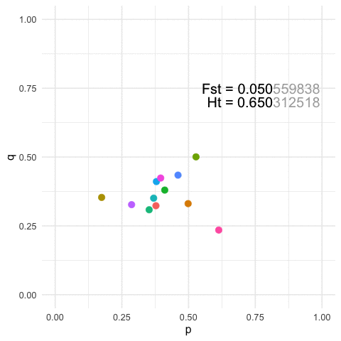

Non-uniqueness of frequency spectra resulting in identical among population (Fst) and within population (Ht) estimates of genetic diversity as demonstrated from allele frequencies for twelve populations for the first two alleles from a three allele locus.

In both of these situations, the relative position and arrangements of the individual populations are not unique. Now, this may not be an issue, if the kinds of questions you are working with do not rely upon interpreting the relative positions of populations in allele space. However, for many population, conservation, and landscape type studies, it is exactly the relative positions of populations that are the focus of the study. As such, to ignore the *irreversibility of structure and diversity statistics* is to pass up on potentially valuable insights on the species and systems you are working with.

## Vectorizing Allelic Spectra

For simplicity, the frequency spectra for individuals and populations will be denoted in vector notation. For example, a locus with $m$ independently assorting alleles is represented as follows

$$\vec{p} = [f_1, f_2, ..., f_m]$$

where each of the $f_i$ frequencies represent the frequency in the individual. For haploid samples, the sample space is $[0,1]$

$$\vec{p}_i = [ \vec{p}_{i,1} | \vec{p}_{i,2} | \vec{p}_{i,3} | \dots | \vec{p}_{i,\ell}]$$

## Within Population Structure

## Consequnce of Missing Data

## Footnotes

[^1]: Wright, S. 1978. [Evolution & the Genetics of Populations 4: Variability within and among natural populations.](https://www.amazon.com/Evolution-Genetics-Populations-Variability-Natural-dp-0226910415/dp/0226910415/ref=mt_other?_encoding=UTF8&me=&qid=) University of Chicago Press. .